# Getting started with graphs

Jing Fang

# This lecture covers

- Introduction to ggplot2
- Getting started with qplot

# 3.1 Welcome to ggplot2

# Welcome to ggplot2

- `ggplot2` is an R package for producing statistical, or data, graphics, but it is unlike most other graphics packages because it has a deep underlying grammar.
- Practically, ggplot2 provides beautiful, hassle-free plots, that take care of fiddly details like drawing legends
- `ggplot2` is designed to work in a layered fashion, starting with a layer showing the raw data then adding layers of annotations and statistical summaries.

# 3.2 Introduction

# Introduction

- In this lecture, you will learn to make a wide variety of plots with your first `ggplot2` function, `qplot()`.
- `qplot`, short for **q**uick plot, make it easy to produce complex plots.

# 3.3 Datasets

# Datasets

- In this lecture, we’ll just use one data sources.
- The `diamonds` dataset consists of prices and quality information about 54,000 diamonds, and is included in the `ggplot2` package.

# Datasets

```r
library(ggplot2)
head(diamonds)
```

```
##   carat       cut color clarity depth table price    x    y    z
## 1  0.23     Ideal     E     SI2  61.5    55   326 3.95 3.98 2.43
## 2  0.21   Premium     E     SI1  59.8    61   326 3.89 3.84 2.31
## 3  0.23      Good     E     VS1  56.9    65   327 4.05 4.07 2.31
## 4  0.29   Premium     I     VS2  62.4    58   334 4.20 4.23 2.63
## 5  0.31      Good     J     SI2  63.3    58   335 4.34 4.35 2.75
## 6  0.24 Very Good     J    VVS2  62.8    57   336 3.94 3.96 2.48
```

# Datasets

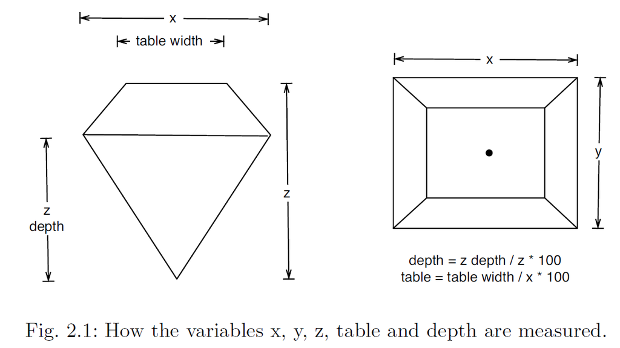

# Datasets

- We’ll also use another dataset, `dsmall`, which is a random sample of 100 diamonds.
- We’ll use this data for plots that are more appropriate for smaller datasets.

```r
set.seed(1410)  # Make the sample reproducible.
dsmall = diamonds[sample(nrow(diamonds), 100), ]
```

# 3.4 Basic use

# Basic use

- The first two arguments to `qplot()` are x and y, giving the x- and y-coordinates for the objects on the plot.
- There is also an optional `data` argument to specify the data frame that `qplot()` will look inside before looking for objects in your workspace.
- Using the `data` argument is recommended.

# Basic use

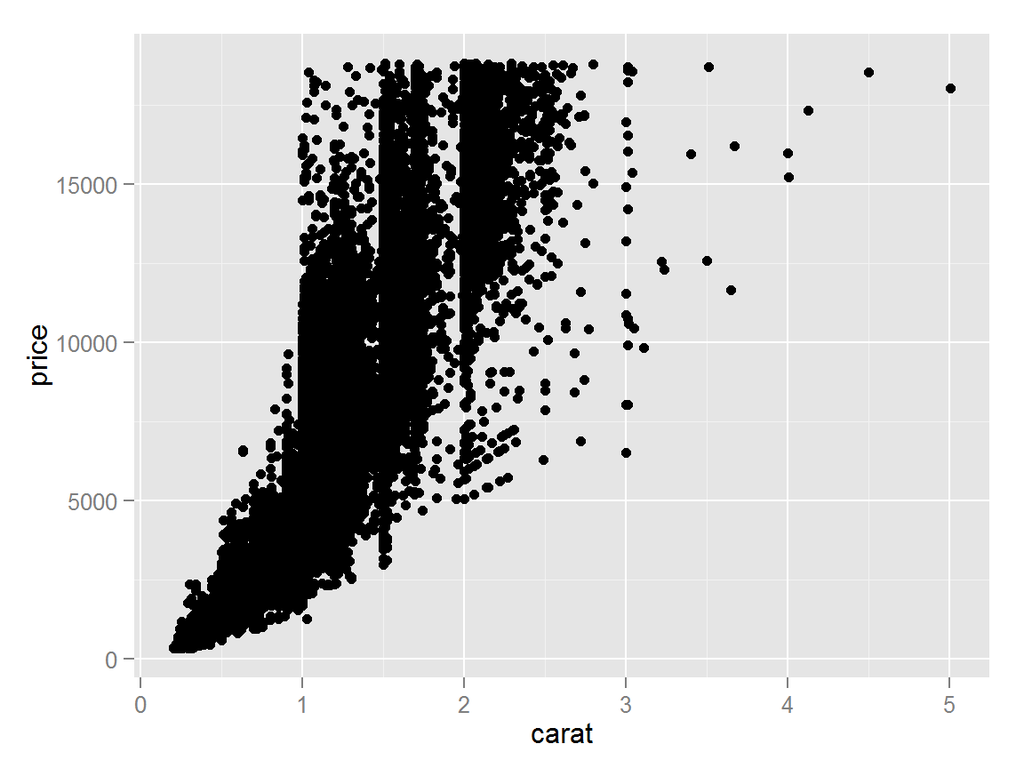

```r
qplot(carat, price, data = diamonds)
```

- The relationship looks exponential, though, so the first thing we’d like to do is to transform the variables.

# Basic use

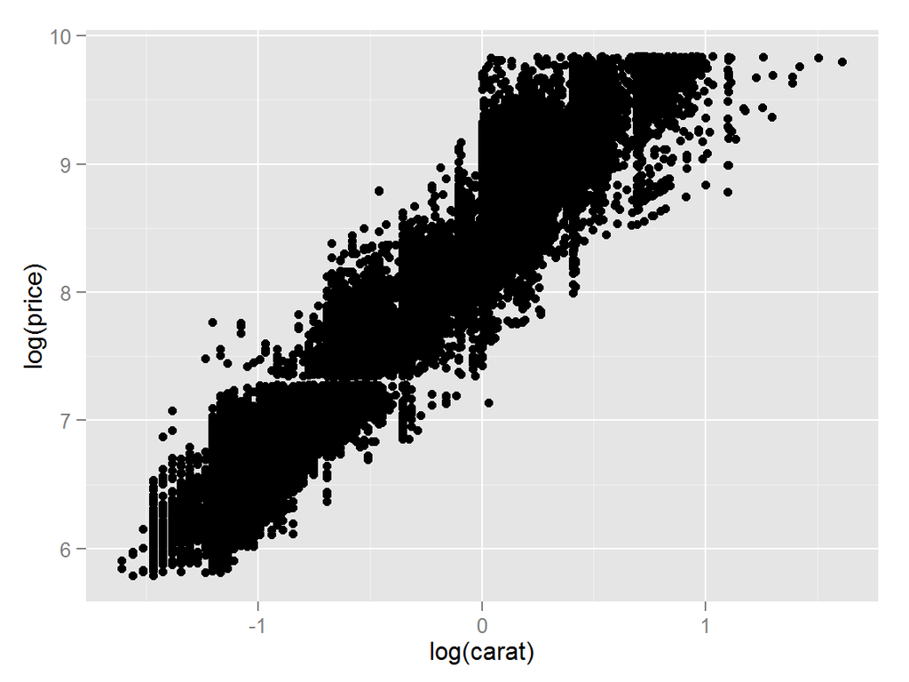

```r
qplot(log(carat), log(price), data = diamonds)
```

- The relationship now looks linear.

# Basic use

- Arguments can also be combinations of existing variables, so, if we are curious about the relationship between the volume of the diamond (approximated by $x\times y\times z$) and its weight, we could do:

```r
qplot(carat, x * y * z, data = diamonds)
```

- We would expect the density of diamonds to be constant.

# Basic use

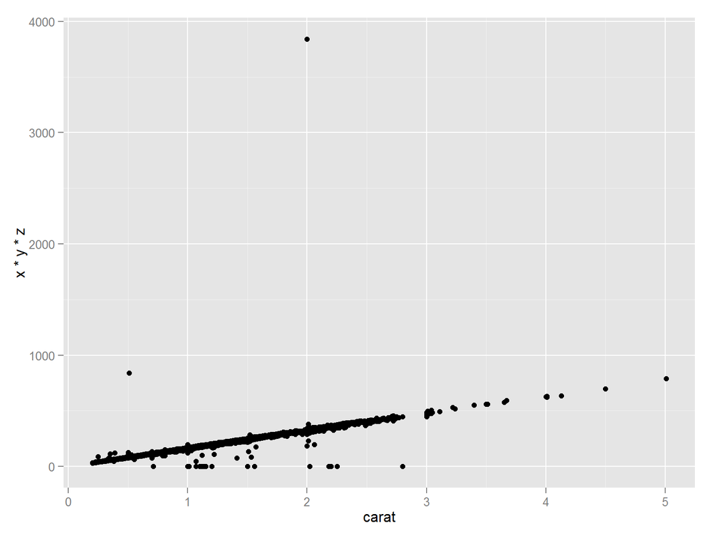

```r
qplot(carat, x * y * z, data = diamonds)
```

# 3.5 Colour, size, shape and other aesthetic attributes

# Colour, size, shape and other aesthetic attributes

- `qplot` can convert a categorical variable in your data into color for you automatically, and it will automatically provide a legend that maps the displayed attributes to the data values.

# Colour, size, shape and other aesthetic attributes

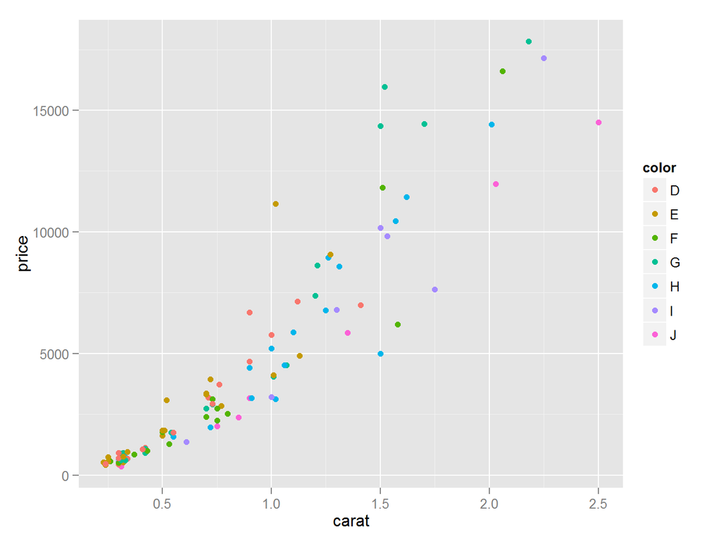

```r
qplot(carat, price, data = dsmall, colour = color)
```

# Colour, size, shape and other aesthetic attributes

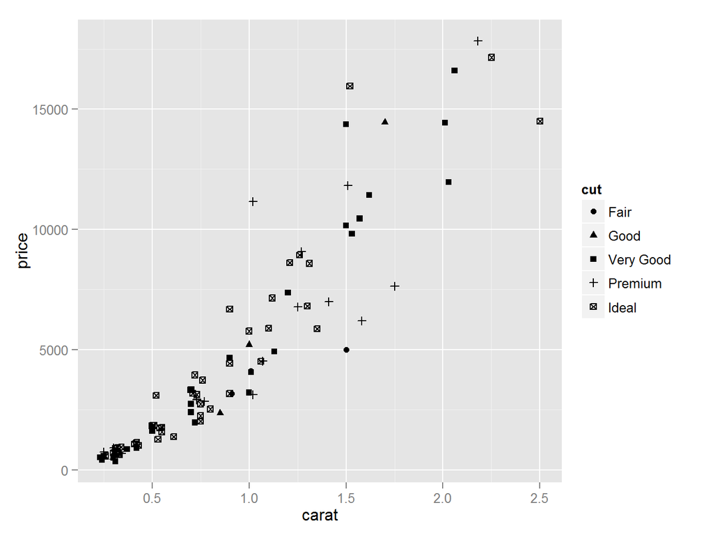

```r
qplot(carat, price, data = dsmall, shape = cut)
```

# Colour, size, shape and other aesthetic attributes

- Color, size and shape are all examples of aesthetic attributes.
- For every aesthetic attribute, there is a function, called a scale, which maps data values to valid values for that aesthetic.
- It is this scale that controls the appearance of the points and associated legend.
- You can also manually set the aesthetics using `I()`, e.g., `colour=I("red")` or `size=I(2)`. This is not the same as mapping.

# Colour, size, shape and other aesthetic attributes

- For large datasets, semi-transparent points are often useful to alleviate some of the overplotting.
- To make a semi-transparent colour you can use the alpha aesthetic, which takes a value between 0 (completely transparent) and 1 (complete opaque).

# Colour, size, shape and other aesthetic attributes

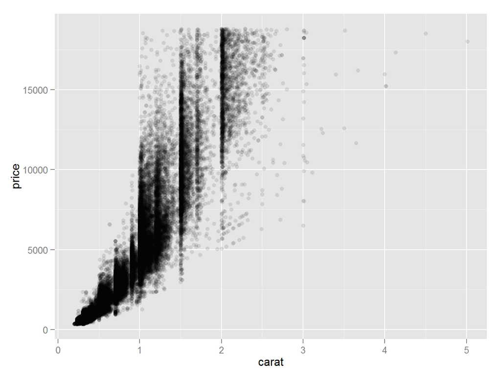

```r
qplot(carat, price, data = diamonds, alpha = I(1/10))
```

# Colour, size, shape and other aesthetic attributes

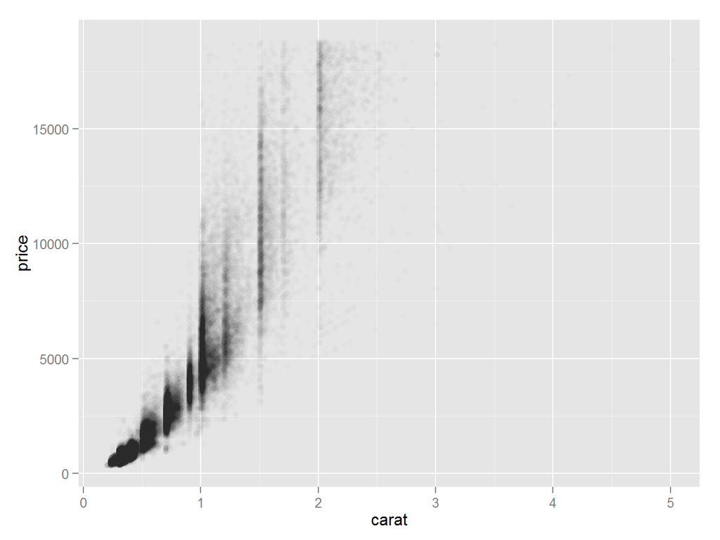

```r
qplot(carat, price, data = diamonds, alpha = I(1/100))
```

# Colour, size, shape and other aesthetic attributes

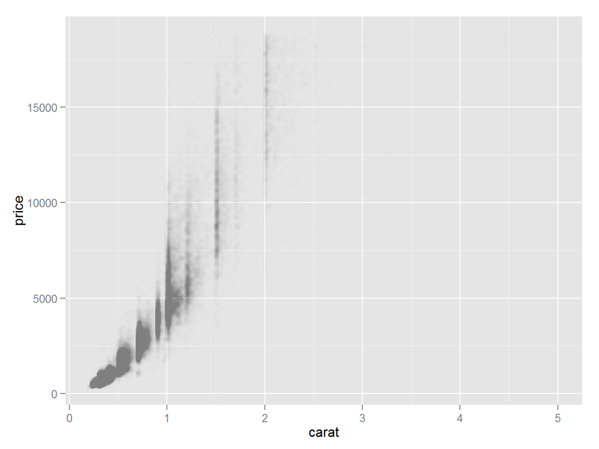

```r
qplot(carat, price, data = diamonds, alpha = I(1/200))
```

# 3.6 Plot geoms

# Plot geoms

- `qplot` is not limited to scatterplot, but can produce almost any kind of plot by varying the `geom`.
  - `geom="point"` draws points to produce a scatterplot. This is the default when you supply both x and y arguments to `qplot()`.
  - `geom="smooth"` fits a smoother to the data and displays the smooth and its standard error.
  - `geom="boxplot"` produces a box-and-whisker plot to summarize the distribution of a set of points.

# Plot geoms

- For 1d distributions, your choice of geoms is guided by the variable type:
  - For continuous variable,
    - `geom="histogram"` draws a histogram. This is the default when you only supply an x value to `qplot()`
    - `geom="freqpoly"` draws a frequency polygon
    - `geom="density"` creates a density plot
  - For discrete variable, `geom="bar"` makes a bar chart.

# Adding a smoother to a plot

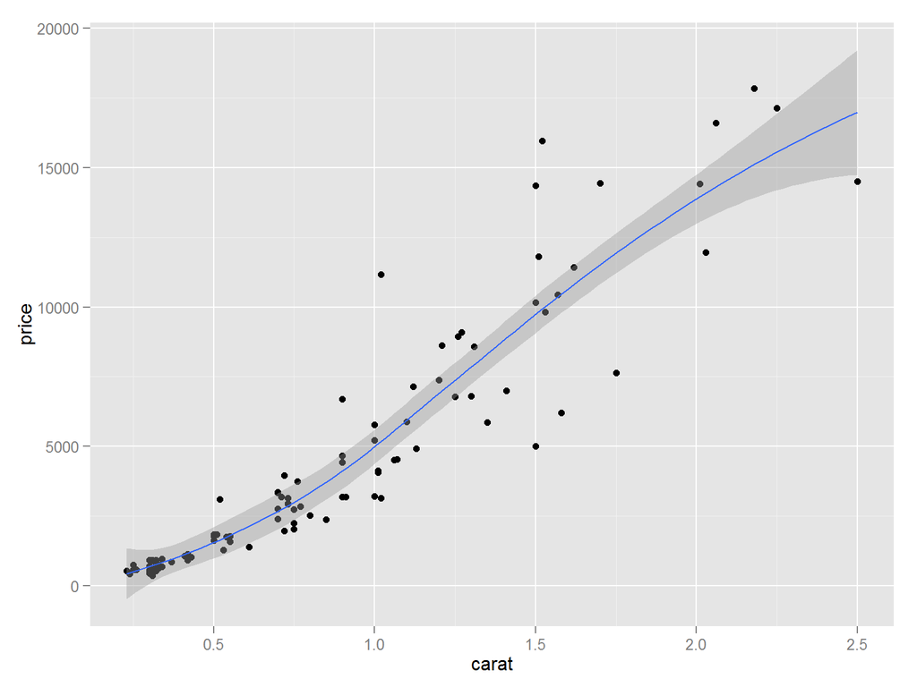

```r
qplot(carat, price, data = dsmall, geom = c("point", "smooth"))
```

# Adding a smoother to a plot

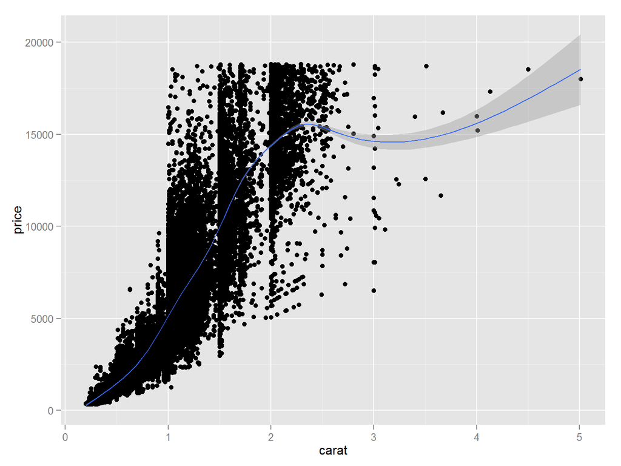

```r
qplot(carat, price, data = diamonds, geom = c("point", "smooth"))
```

# Adding a smoother to a plot

- If you want to turn the confidence interval off, use `se=FALSE`.
- There are many different smoothers you can choose between by using the method argument:
  - `method="loess"`, the default for small n, uses a smooth local regression to fit a polynomial surface determined by one or more numerical predictors.
  - `method="lm"` fits a linear model.

# Adding a smoother to a plot

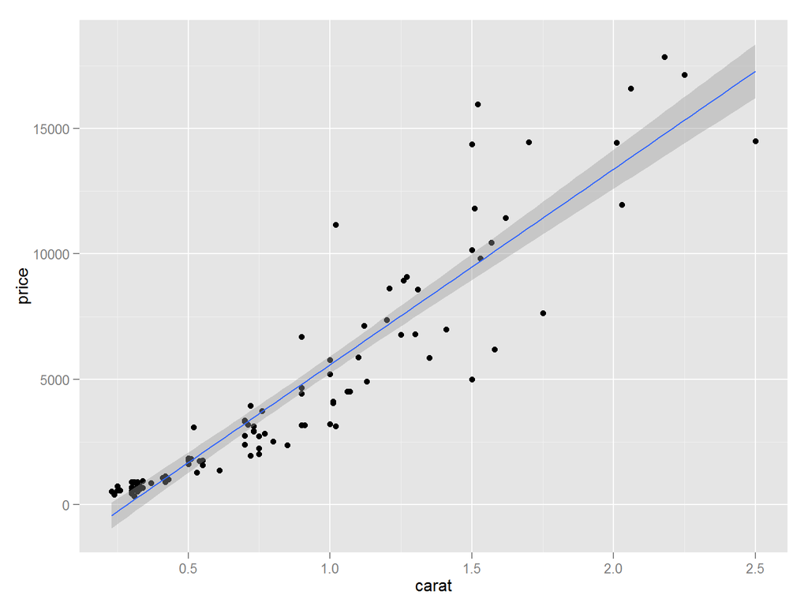

```r
qplot(carat, price, data = dsmall, geom = c("point", "smooth"), method = "lm")
```

# Boxplots and jittered points

- When a set of data includes a categorical variable and one or more continuous variables, you will probably be interested to know how the values of the continuous variables vary with the levels of the categorical variable.
- Boxplots and jittered points offer two ways to do this.
- Each method has its strengths and weaknesses.
  - Boxplots summarize the bulk of the distribution with only five numbers;
  - Jittered plots show every point but can suffer from overplotting.
- The overplotting seen in the plot of jittered values can be alleviated somewhat by using semi-transparent points using the `alpha` argument.

# Boxplots and jittered points

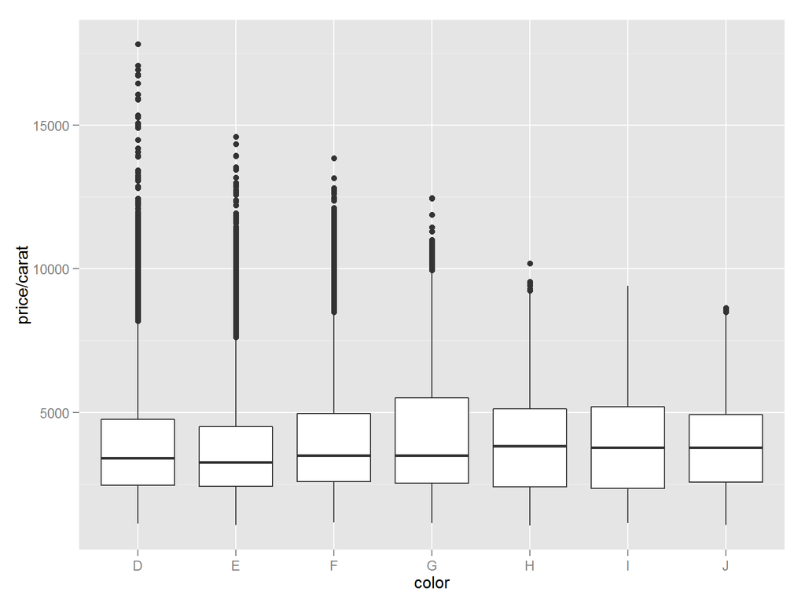

```r
qplot(color, price/carat, data = diamonds, geom = "boxplot")
```

# Boxplots and jittered points

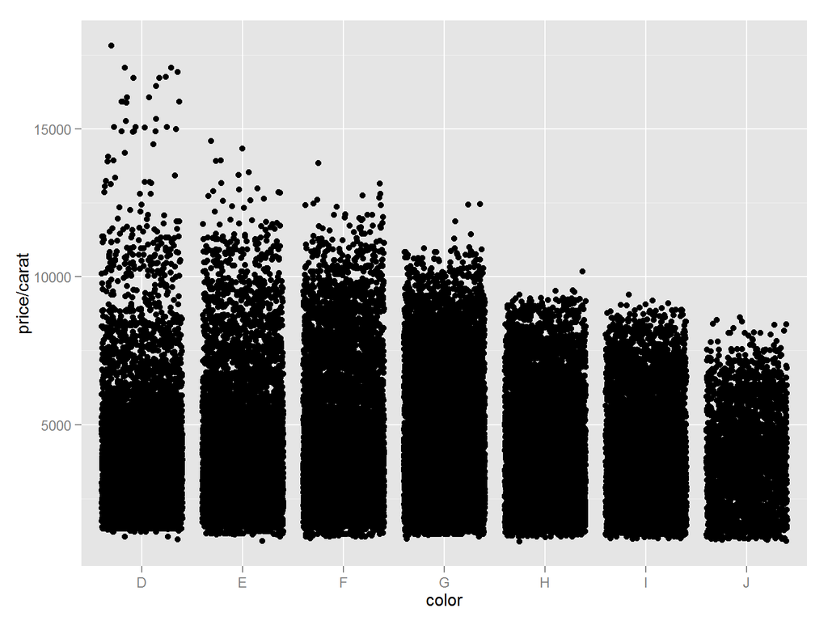

```r
qplot(color, price/carat, data = diamonds, geom = "jitter")
```

# Boxplots and jittered points

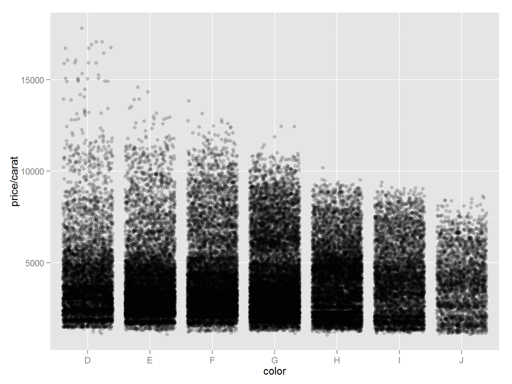

```r
qplot(color, price/carat, data = diamonds, geom = "jitter", alpha = I(1/5))
```

# Boxplots and jittered points

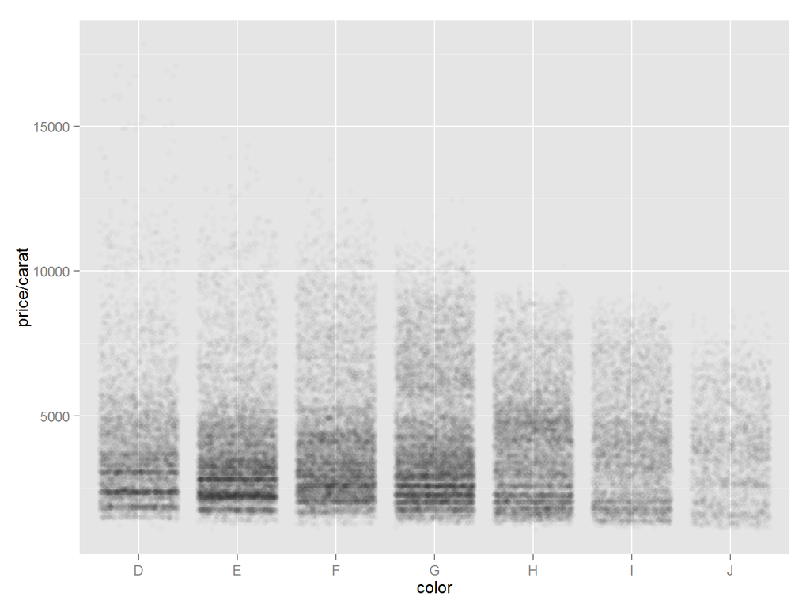

```r
qplot(color, price/carat, data = diamonds, geom = "jitter", alpha = I(1/50))
```

# Boxplots and jittered points

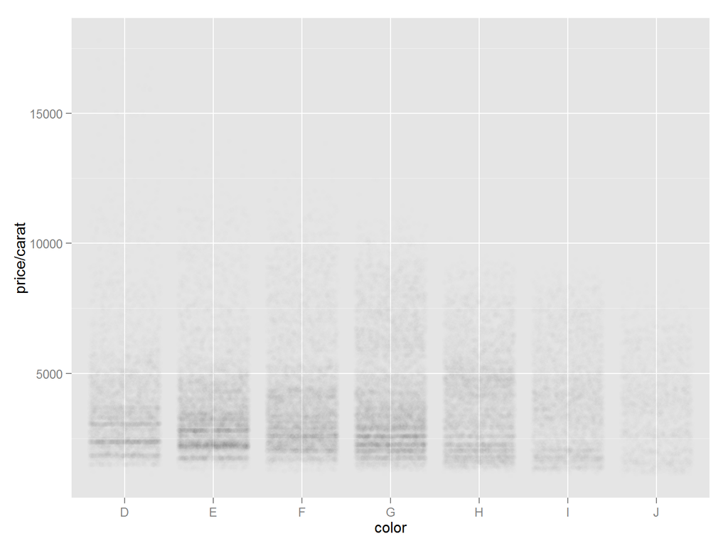

```r
qplot(color, price/carat, data = diamonds, geom = "jitter", alpha = I(1/200))
```

# Boxplots and jittered points

- This technique can’t show the positions of the quartiles as well as a boxplot can, but it may reveal other features of the distribution that a boxplot cannot.
- For jittered points, qplot offers the same control over aesthetics: `size`, `colour` and `shape`.
- For boxplots you can control the outline `colour`, the internal `fill` colour and the `size` of the lines.

# Histogram and density plots

- Histogram and density plots show the distribution of a single variable.
- They provide more information about the distribution of a single group than boxplots do, but it is harder to compare many groups.
- For the histogram, the `binwidth` argument controls the amount of smoothing by setting the bin size.
- It is **very important** to experiment with the level of smoothing.

# Histogram and density plots

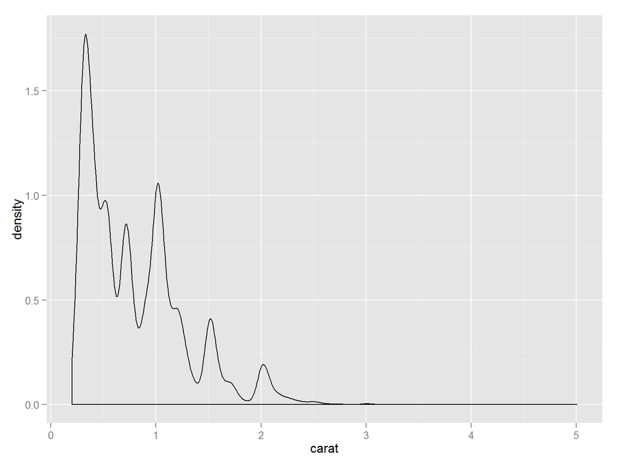

```r
qplot(carat, data = diamonds, geom = "density")
```

# Histogram and density plots

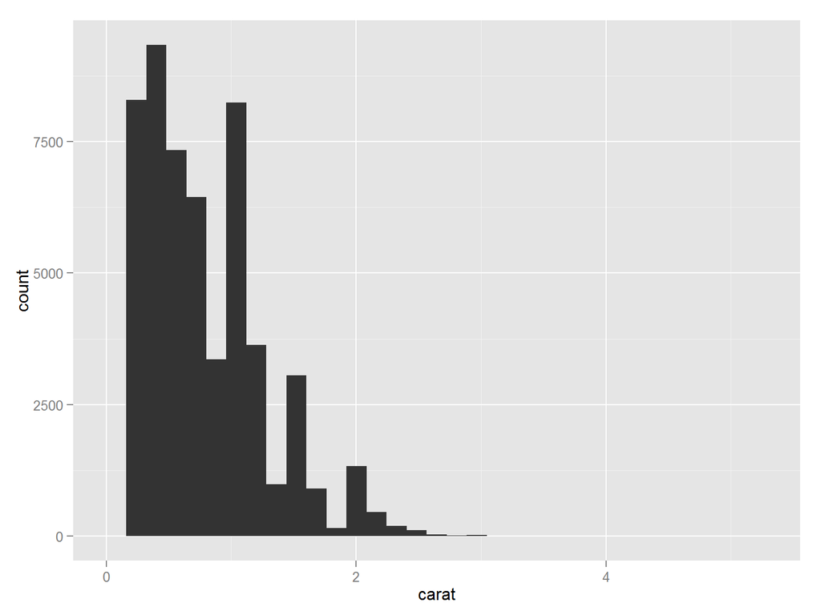

```r
qplot(carat, data = diamonds, geom = "histogram")
```

# Histogram and density plots

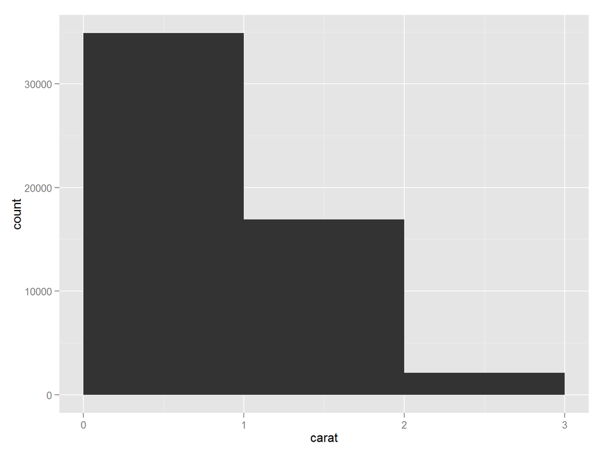

```r
qplot(carat, data = diamonds, geom = "histogram", binwidth = 1, xlim = c(0,
    3))
```

# Histogram and density plots

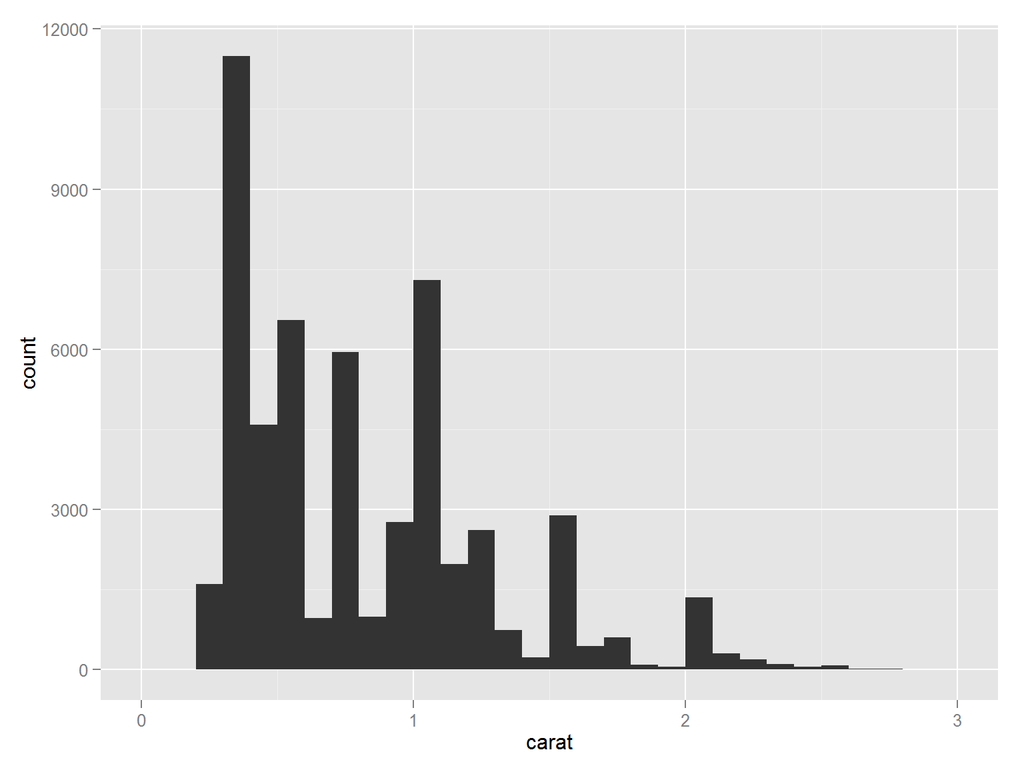

```r
qplot(carat, data = diamonds, geom = "histogram", binwidth = 0.1, xlim = c(0,
    3))
```

# Histogram and density plots

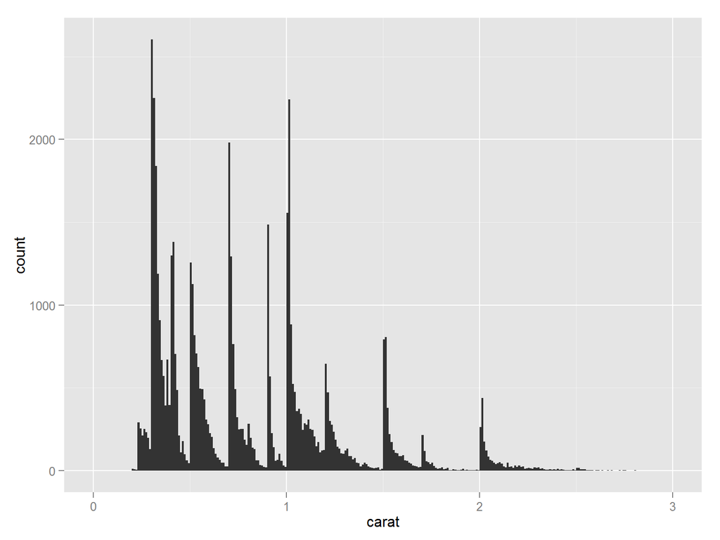

```r
qplot(carat, data = diamonds, geom = "histogram", binwidth = 0.01, xlim = c(0,
    3))
```

# Histogram and density plots

- To compare the distributions of different subgroups, just add an aesthetic mapping.
- Mapping a categorical variable to an aesthetic will automatically split up the geom by that variable.

# Histogram and density plots

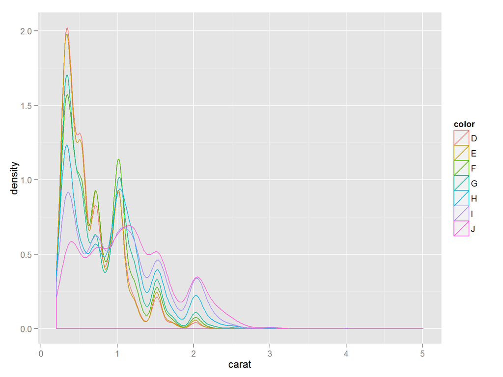

```r
qplot(carat, data = diamonds, geom = "density", colour = color)
```

# Histogram and density plots

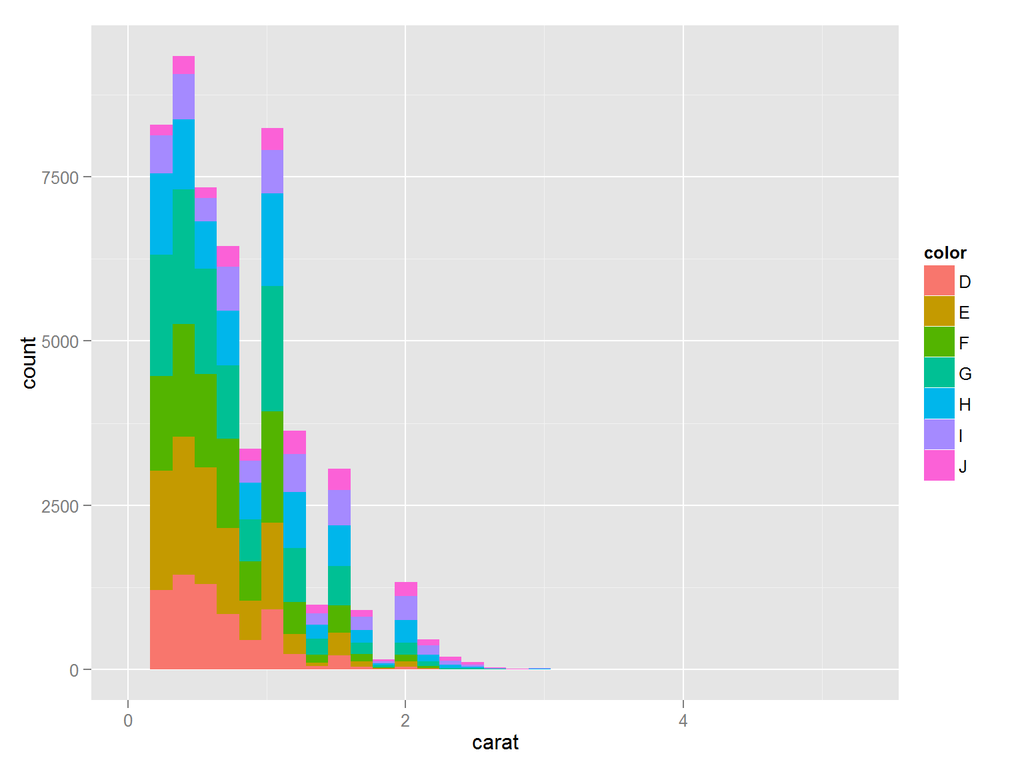

```r
qplot(carat, data = diamonds, geom = "histogram", fill = color)
```

# Bar charts

- The discrete analogue of histogram is the bar chart, `geom="bar"`.
- The bar geom counts the number of instances of each class automatically.
- If you like to tabulate class members in some other way, you can use `weight` geom

# Bar charts

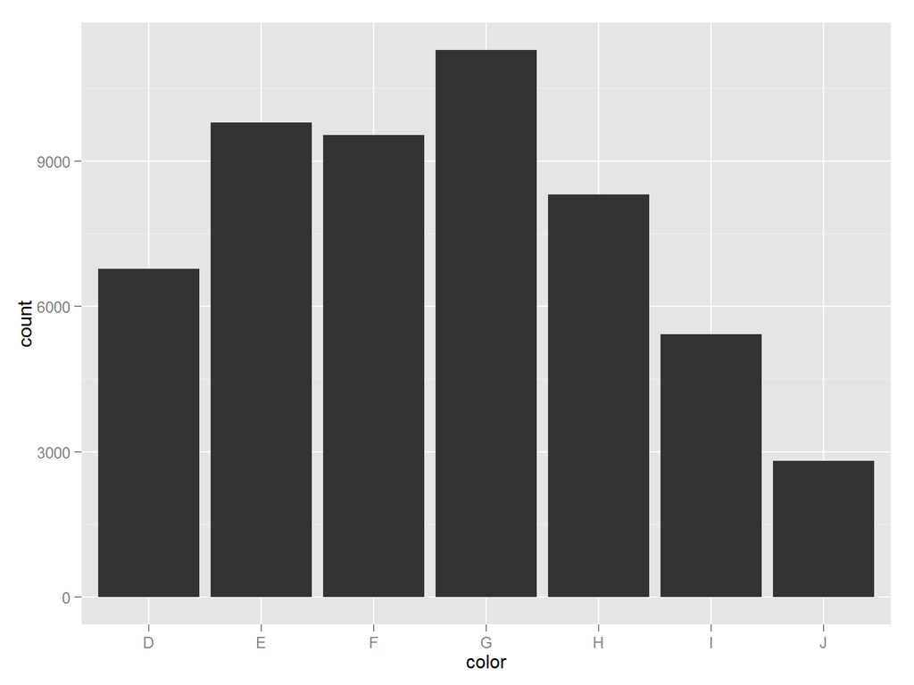

```r
qplot(color, data = diamonds, geom = "bar")
```

# Bar charts

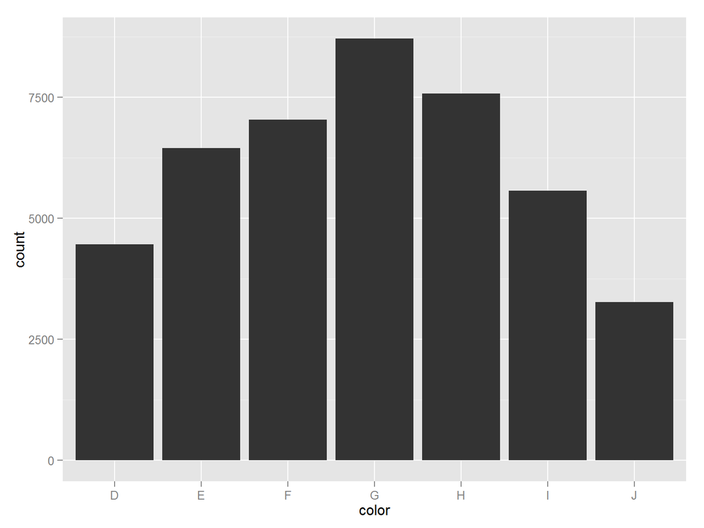

```r
qplot(color, data = diamonds, geom = "bar", weight = carat)
```

# Faceting

- Faceting creates tables of graphics by splitting the data into subsets and displaying the same graph for each subset in an arrangement that facilitates comparison.
- The default faceting method in `qplot()` creates plots arranged on a grid specified by a faceting formula which looks like `row_var~col_var`.
- You can specify as many row and column variables as you like.
- To facet on only one of columns or rows, use ‘.’ as a place holder.

# Faceting

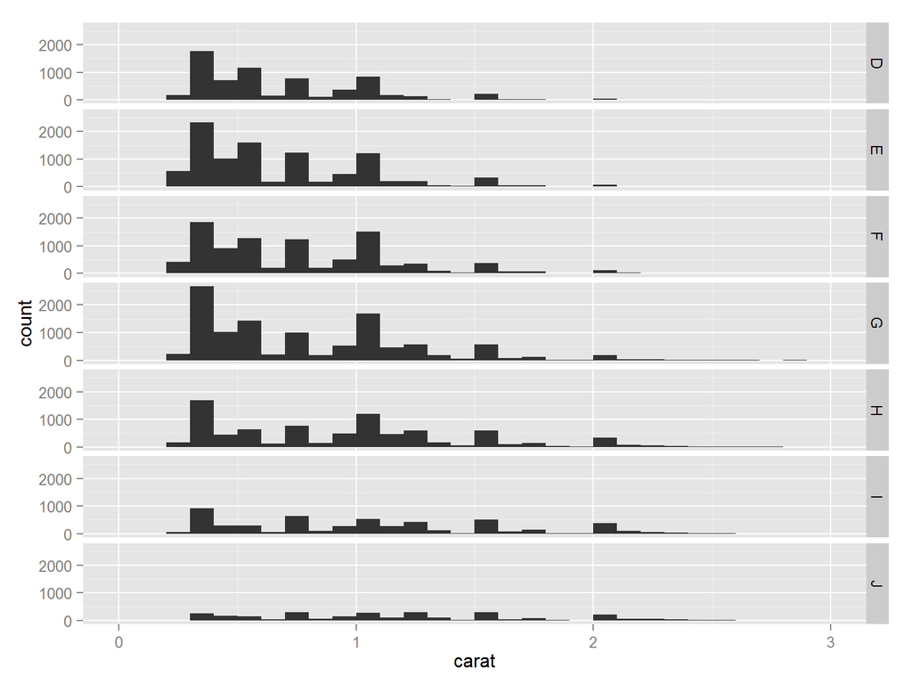

```r
qplot(carat, data = diamonds, facets = color ~ ., geom = "histogram", bindwidth = 0.1,
    xlim = c(0, 3))
```

# Faceting

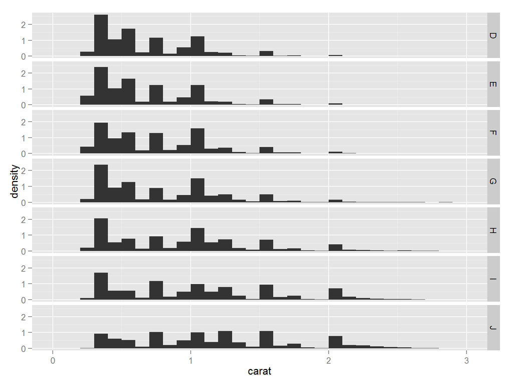

```r
qplot(carat, ..density.., data = diamonds, facets = color ~ ., geom = "histogram",
    bindwidth = 0.1, xlim = c(0, 3))
```

# Other options

- There are a few other `qplot` options to control the graphic’s appearance.
  - `xlim`, `ylim`: set limits for the x- and y-axes.
  - `log`: a character vector indicating which axes should be logged.
  - `main`: main title for the plot.
  - `xlab`, `ylab`: labels for the x- and y-axes.
- The following examples show the options in action.

# Other options

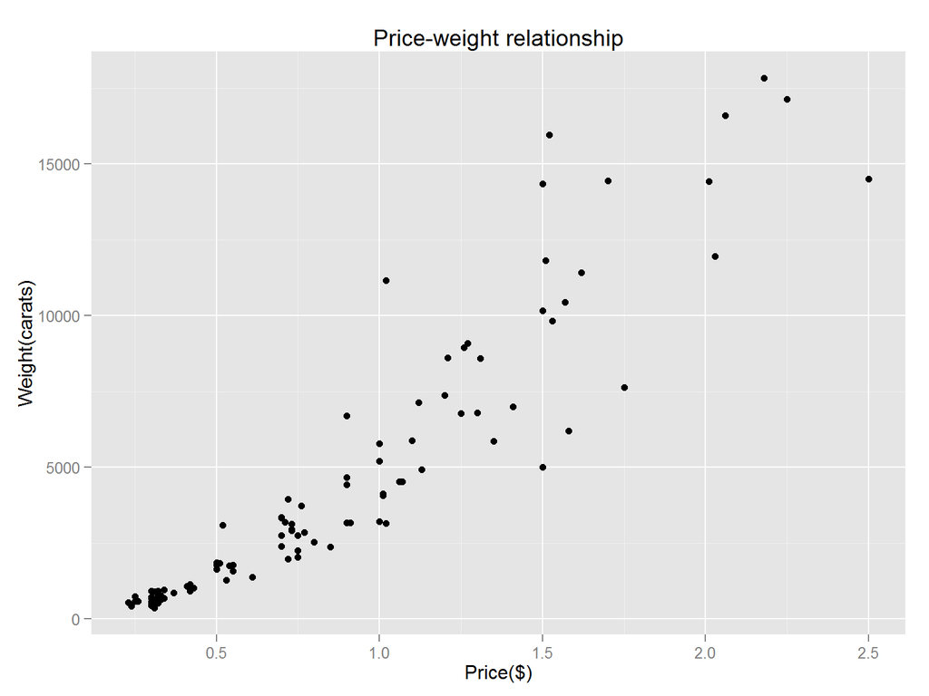

```r
qplot(carat, price, data = dsmall, xlab = "Price($)", ylab = "Weight(carats)",
    main = "Price-weight relationship")
```

# Other options

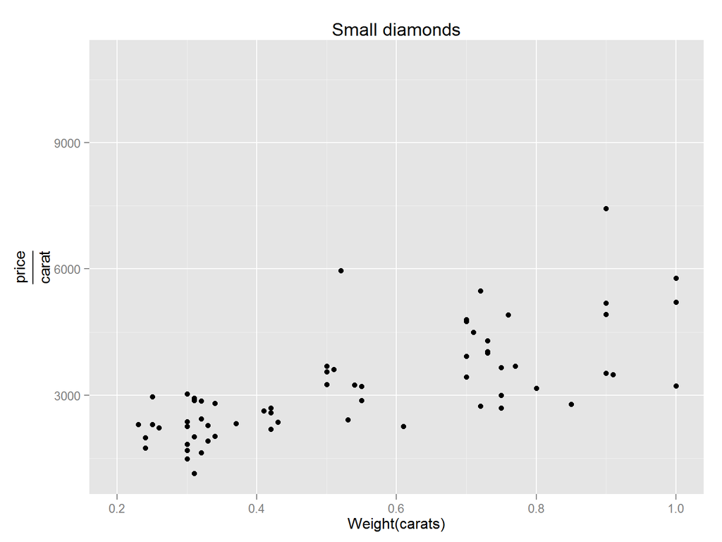

```r
qplot(carat, price/carat, data = dsmall, xlab = "Weight(carats)", ylab = expression(frac(price,
    carat)), main = "Small diamonds", xlim = c(0.2, 1))
```

# Other options

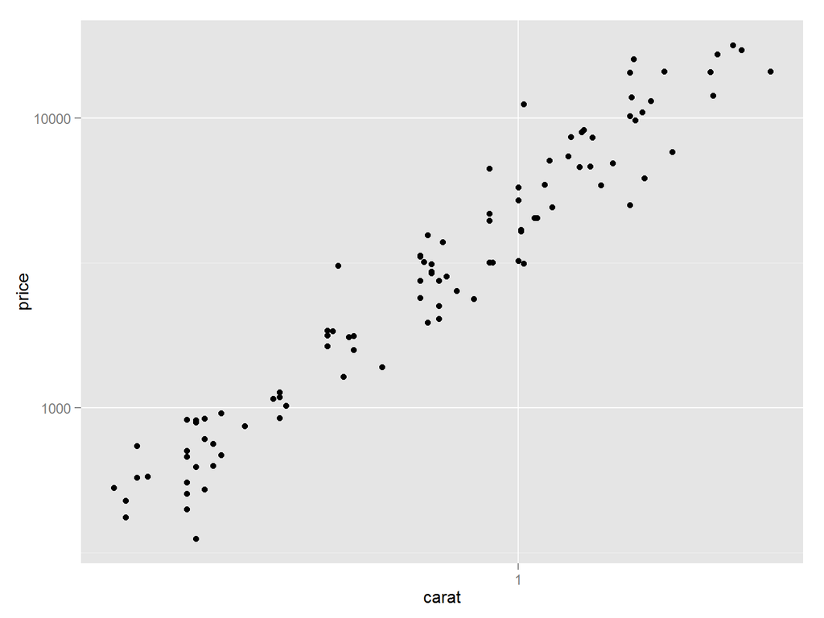

```r
qplot(carat, price, data = dsmall, log = "xy")
```